# Structural Equation Models 2019

## Week 5

### Exercise 5.1

The subject of this exercise are the relations among the three dimensions of burnout and their invariance across elementary and secondary teachers. The data files consist of elementary (N=580) and secondary (N=692) teachers with 22 MBI items. The aim is to test the invariance of MBI across the samples.

Let us import the data file in R, prepare the data and build the model according to the input file.

Fit indices (Model 1)

| Group | Chi.square | df | p.value | Scaling.correction.factor | CFI | TLI | RMSEA | SRMR |
| --- | --- | --- | --- | --- | --- | --- | --- | --- |
| Elementary | 802.7431 | 206 | 0 | 1.261 | 0.858 | 0.841 | 0.079 | 0.071 |
| Secondary | 971.0638 | 206 | 0 | 1.321 | 0.835 | 0.815 | 0.084 | 0.080 |

The fit indices of the initial models are shown in table 1. The scaling correction factor indices (1.261 and 1.321) support the use of MLM robust estimators. All fit indices imply poor fit of both models (p < 0.001 [df=206], CFI < 0.9, TLI <0.9, RMSEA > 0.05). Let us continue to model modification.

### Modification indices

```
##        lhs op    rhs      mi    epc sepc.lv sepc.all sepc.nox
## 158  ITEM6 ~~ ITEM16 180.298  0.893   0.893    0.595    0.595
## 95   ITEM1 ~~  ITEM2 103.177  0.534   0.534    0.494    0.494
## 59      EE =~ ITEM12  81.319 -0.400  -0.515   -0.400   -0.400
## 260 ITEM10 ~~ ITEM11  67.743  0.688   0.688    0.832    0.832
## 323 ITEM18 ~~ ITEM19  43.669  0.279   0.279    0.340    0.340
## 298  ITEM4 ~~  ITEM7  42.833  0.184   0.184    0.294    0.294
```

```
##        lhs op    rhs      mi    epc sepc.lv sepc.all sepc.nox
## 95   ITEM1 ~~  ITEM2 171.647  0.627   0.627    0.583    0.583
## 260 ITEM10 ~~ ITEM11 135.841  1.181   1.181    1.426    1.426
## 158  ITEM6 ~~ ITEM16 127.756  0.686   0.686    0.458    0.458
## 59      EE =~ ITEM12 118.156 -0.468  -0.561   -0.419   -0.419
## 250  ITEM5 ~~ ITEM15  77.216  0.580   0.580    0.355    0.355
## 271 ITEM11 ~~ ITEM15  60.947 -0.485  -0.485   -0.420   -0.420
## 122  ITEM2 ~~ ITEM20  53.024 -0.324  -0.324   -0.316   -0.316
## 249  ITEM5 ~~ ITEM11  48.297 -0.446  -0.446   -0.369   -0.369
## 314  ITEM9 ~~ ITEM19  46.617  0.360   0.360    0.358    0.358
## 52      EE =~ ITEM10  45.623 -0.394  -0.473   -0.302   -0.302
```

The results (modification indices MI and expected parameter change EPC) suggest that we should add ITEM6 ~~ ITEM16, ITEM1 ~~ ITEM2 and ITEM10 ~~ ITEM1. Also a cross-loading of item 12 on factor F1 (EE) is implied. These results are shared in both groups. Let us modify the model:

### Model 2

Fit indices (Model 2)

| Group | Chi.square | df | p.value | Scaling.correction.factor | CFI | TLI | RMSEA | SRMR |
| --- | --- | --- | --- | --- | --- | --- | --- | --- |
| Elementary | 470.3767 | 202 | 0 | 1.243 | 0.937 | 0.928 | 0.053 | 0.053 |
| Secondary | 572.5523 | 202 | 0 | 1.311 | 0.921 | 0.909 | 0.059 | 0.058 |

The indices improved quite a lot for both models, but we need to continue modifying the model:

### Modification indices

```
##        lhs op    rhs     mi   epc sepc.lv sepc.all sepc.nox
## 305  ITEM4 ~~  ITEM7 38.931 0.174   0.174    0.284    0.284
## 323 ITEM18 ~~ ITEM19 38.744 0.266   0.266    0.333    0.333
```

```
##       lhs op    rhs     mi   epc sepc.lv sepc.all sepc.nox
## 57     EE =~ ITEM11 67.177 0.472   0.532    0.339    0.339
## 318 ITEM9 ~~ ITEM19 43.690 0.355   0.355    0.357    0.357
## 263 ITEM5 ~~ ITEM15 35.576 0.416   0.416    0.310    0.310
```

In the group of elementary teachers, items 4 and 7 have the highest values for the residual covariance. The group of secondary teachers has the highest MI value for the cross-loading of item 11 on F1. We must specify model 3 separately for these groups according to these findings.

### Model 3

Fit indices (Model 3)

| Group | Chi.square | df | p.value | Scaling.correction.factor | CFI | TLI | RMSEA | SRMR |
| --- | --- | --- | --- | --- | --- | --- | --- | --- |
| Elementary | 445.8005 | 201 | 0 | 1.224 | 0.944 | 0.935 | 0.051 | 0.051 |
| Secondary | 522.9823 | 201 | 0 | 1.307 | 0.931 | 0.921 | 0.055 | 0.055 |

### Modification indices

```
##        lhs op    rhs     mi   epc sepc.lv sepc.all sepc.nox
## 323 ITEM18 ~~ ITEM19 32.503 0.247   0.247    0.319    0.319
```

```
##       lhs op    rhs     mi   epc sepc.lv sepc.all sepc.nox
## 318 ITEM9 ~~ ITEM19 42.687 0.351   0.351    0.355    0.355
```

The MI and EPC values imply that continuing modification is not needed for the elementary teachers group. According to MI and EPC values the model for secondary teachers group can be fine tuned further by allowing residual covariance of items 9 and 19. Model 4 will be done separately for secondary teachers group only.

### Model 4

Fit indices (Model 4)

|  | Group | Chi.square | df | p.value | Scaling.correction.factor | CFI | TLI | RMSEA | SRMR |
| --- | --- | --- | --- | --- | --- | --- | --- | --- | --- |
| chisq.scaled | Secondary | 492.2819 | 200 | 0 | 1.308 | 0.938 | 0.928 | 0.053 | 0.054 |

Now we have achieved baseline models for both teacher groups. Let us print their fit indices:

Fit indices (Baseline models)

| Group | Chi.square | df | p.value | Scaling.correction.factor | CFI | TLI | RMSEA | SRMR |
| --- | --- | --- | --- | --- | --- | --- | --- | --- |
| Elementary | 445.8005 | 201 | 0 | 1.224 | 0.944 | 0.935 | 0.051 | 0.051 |
| Secondary | 492.2819 | 200 | 0 | 1.308 | 0.938 | 0.928 | 0.053 | 0.054 |

### Exercise 5.2

Let us combine the groups and specify the common baseline (configural) model and draw the graphs.

```
##         chisq.scaled            df.scaled        pvalue.scaled
##              958.341              401.000                0.000
## chisq.scaling.factor           cfi.robust           tli.robust
##                1.242                0.940                0.930
##         rmsea.robust
##                0.052
```

Graphs of the common baseline model (configural model) are presented below. The first graph is for the elementary school teachers and the second graph is for the secondary school teachers.

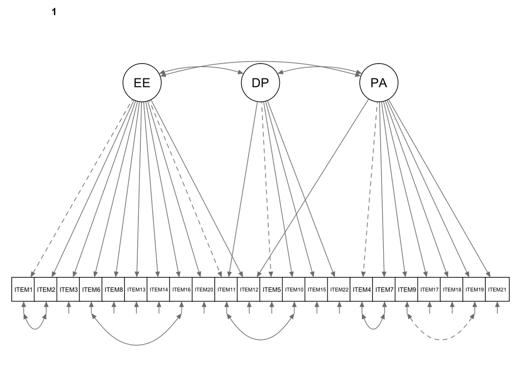

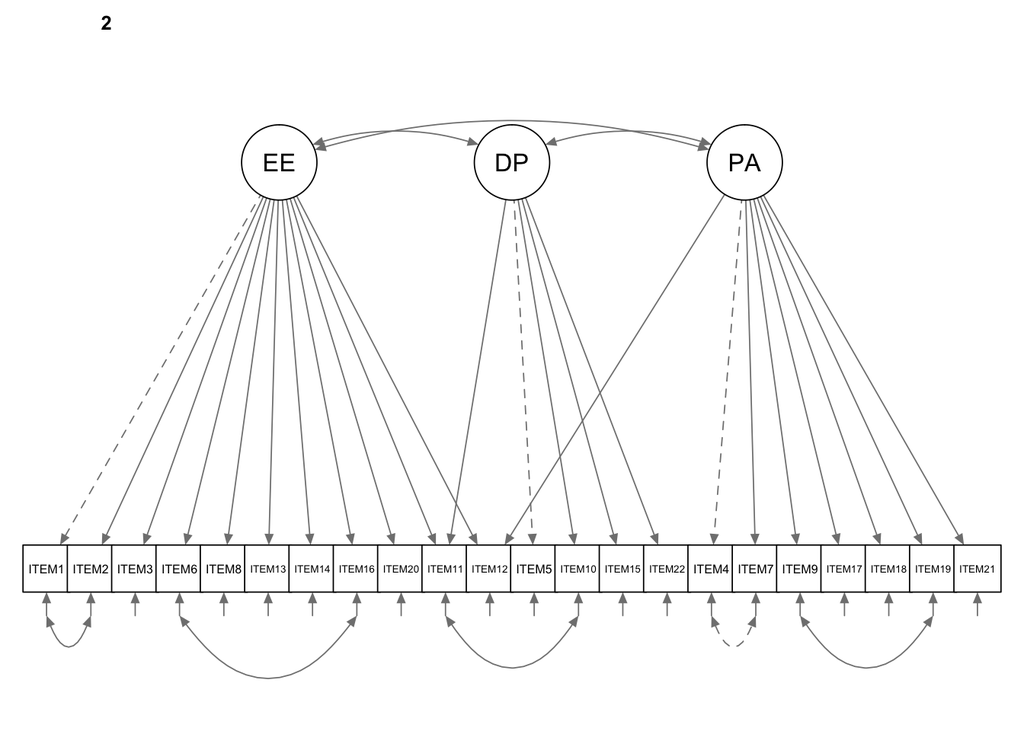